# Run Principal Components Analysis (PCA) and plot results

Zhe Zhang

2019-03-15

This procedure runs Principal Components Analysis (PCA) for quality control and sample analysis purposes. It uses a data matrix of variables (rows) and samples (columns), such as a normalized transcriptome data set, as input, and plots results based on one or multipel sample characteristics, .

*[Go to project home](http://zhezhangsh.github.io/RoCA)*

# 1 Description

## 1.1 Project

Perturbed rhythmic activation of signaling pathways in mice deficient for Sterol Carrier Protein 2-dependent diurnal lipid transport and metabolism. (**GSE67426**)

## 1.2 PubMed

Jouffe C, Gobet C, Martin E, Métairon S et al. Perturbed rhythmic activation of signaling pathways in mice deficient for Sterol Carrier Protein 2-dependent diurnal lipid transport and metabolism. Sci Rep 2016 Apr 21;6:24631. PMID: 27097688.

## 1.3 Experimental design

Comparison of liver mRNA expression from Scp2 KO and wild-type mice harvested every 2 hours during 3 consecutive days.

## 1.4 Analysis

This analysis runs PCA using the data of wild type mice and a subset of genes with high between sample variance.

*[Go to project home](http://zhezhangsh.github.io/RoCA)*

# 2 Analysis and results

## 2.1 Run PCA

Principal Components Analysis is run on **2577** variables and **36** samples.

### 2.1.1 Variance proportion

Total variance contributed by each PC.

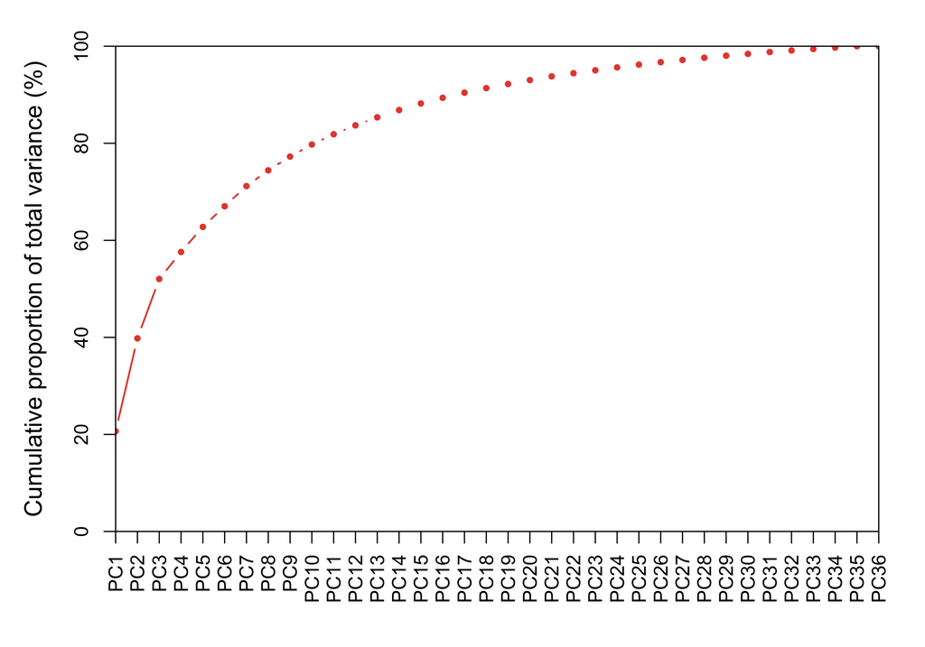

**Figure 1.** Cummulative variance contributed by ordered PCs. Click link below to view full table:

> PCA summary (Download)

*[Go to project home](http://zhezhangsh.github.io/RoCA)*

### 2.1.2 Sample covariance

Covariance of each PC by samples.

**Table 1.** Sample covariance of first 8 PCs. Click link below to view all PCs.

> Full covariance table (Download)

|  | PC1 | PC2 | PC3 | PC4 | PC5 | PC6 | PC7 | PC8 |
| --- | --- | --- | --- | --- | --- | --- | --- | --- |
| WT_00Hr_1 | -5.3653 | 0.4297 | -0.3260 | 2.9211 | -1.0051 | 0.5299 | -2.5754 | 1.0975 |
| WT_00Hr_2 | -5.5159 | 1.1305 | -0.3443 | 1.6171 | -2.6989 | 2.0381 | 3.4381 | -0.4878 |
| WT_00Hr_3 | -5.5803 | 0.7641 | -2.2733 | -5.0217 | 0.4280 | -0.0552 | -0.4308 | 0.3637 |
| WT_02Hr_1 | -6.2424 | -2.0961 | 0.5513 | 2.1851 | -2.1005 | 0.4040 | -1.5719 | 1.1051 |
| WT_02Hr_2 | -6.2833 | -1.0597 | -1.1712 | 2.1795 | 0.7454 | 1.8716 | -3.5054 | 0.9653 |
| WT_02Hr_3 | -6.6739 | -1.4789 | -0.7135 | -3.6441 | -2.4900 | -2.9372 | 2.4520 | -2.2807 |
| WT_04Hr_1 | -6.2174 | -3.0287 | -0.1887 | 3.0080 | -2.6233 | 1.0742 | -2.7248 | 1.6584 |
| WT_04Hr_2 | -3.5803 | -7.1737 | -1.3746 | 1.1111 | 2.8587 | 2.4888 | -2.4172 | 0.6770 |
| WT_04Hr_3 | -5.6291 | -2.9376 | -3.7645 | -0.9480 | -4.9302 | 0.1865 | -0.9530 | -0.6430 |
| WT_06Hr_1 | -2.7732 | -7.7162 | 1.2366 | 1.6612 | 2.0917 | -2.4826 | 0.4154 | 0.7859 |
| WT_06Hr_2 | -2.7276 | -6.2334 | -0.7832 | 0.1404 | 1.8661 | 2.9411 | -0.6162 | 2.4746 |
| WT_06Hr_3 | -1.4733 | -5.6720 | 0.0014 | -3.0785 | -3.6296 | -0.4545 | 2.2566 | 1.8753 |
| WT_08Hr_1 | 3.3669 | -7.9168 | 5.1325 | 1.8984 | -0.6489 | -0.9367 | 4.4768 | 1.0138 |
| WT_08Hr_2 | 2.5534 | -7.5441 | 2.6989 | -0.2472 | 0.2528 | 1.5924 | 0.1400 | 0.0760 |
| WT_08Hr_3 | 3.4187 | -8.0227 | 1.0088 | -3.7609 | 3.0087 | -0.8807 | -1.1447 | 1.6713 |
| WT_10Hr_1 | 7.0086 | -2.3789 | 4.4519 | -0.5140 | -0.0560 | -0.5030 | 1.1038 | 1.1676 |
| WT_10Hr_2 | 6.0623 | -5.6915 | 5.0846 | 0.0447 | 0.5605 | 3.8388 | -2.1658 | -10.3869 |
| WT_10Hr_3 | 5.6923 | -3.8802 | 2.1214 | -2.2565 | 1.7470 | -2.8569 | -1.5845 | -0.0495 |
| WT_12Hr_1 | 7.0959 | -3.1205 | 5.2216 | 2.5552 | -1.8742 | -1.7857 | 4.1083 | 1.0528 |
| WT_12Hr_2 | 13.8210 | -4.3316 | -19.9750 | 2.7597 | -2.2019 | -1.9665 | -0.3363 | -1.0988 |
| WT_12Hr_3 | 8.9042 | 1.7038 | 2.4947 | -2.7234 | 1.5983 | -2.0569 | -1.0050 | 1.9138 |
| WT_14Hr_1 | 6.6249 | 5.3288 | 3.9825 | 0.7294 | -0.4218 | 1.2382 | -3.6207 | 2.0477 |
| WT_14Hr_2 | 6.2264 | 5.3059 | 2.7643 | 0.2601 | -3.3886 | 3.3259 | -0.3437 | 0.3636 |
| WT_14Hr_3 | 6.2558 | 5.6946 | 0.9185 | -1.7285 | -2.1836 | 0.0007 | -2.8577 | 1.7289 |
| WT_16Hr_1 | 1.0736 | 7.5955 | 1.3889 | 5.4132 | 2.2498 | -2.3144 | -2.2245 | -0.4224 |
| WT_16Hr_2 | 2.6759 | 8.9629 | 0.2309 | 2.3421 | -1.1684 | 1.8990 | 1.9425 | -0.1360 |
| WT_16Hr_3 | 2.2867 | 7.8590 | 0.3350 | -2.5114 | -0.5044 | 1.0376 | -1.6665 | 0.4380 |
| WT_18Hr_1 | -0.6720 | 6.9389 | 1.0837 | 2.8253 | 2.5081 | -4.0850 | 0.6424 | -0.4941 |
| WT_18Hr_2 | -0.6742 | 5.9112 | -0.2043 | 3.0885 | -2.6176 | 3.3454 | 5.1242 | -0.0099 |
| WT_18Hr_3 | -1.3937 | 7.4054 | -1.5594 | -4.6959 | 0.3105 | -0.7569 | -1.1090 | -0.9206 |
| WT_20Hr_1 | -4.7818 | 2.1605 | 0.5838 | 2.8258 | 1.5735 | -4.0793 | 1.9793 | -2.0699 |
| WT_20Hr_2 | -0.6059 | 2.9931 | -5.4097 | 0.1671 | 10.3066 | 4.2656 | 4.7302 | 0.6877 |
| WT_20Hr_3 | -1.1810 | 4.8705 | -1.4282 | -6.4638 | 0.8340 | 0.9059 | 1.5513 | -0.0407 |
| WT_22Hr_1 | -5.8241 | 2.0295 | 0.7671 | 1.8468 | 2.1727 | -5.7238 | -2.1027 | -1.7066 |
| WT_22Hr_2 | -4.5364 | 0.6434 | -1.2366 | -0.5499 | 0.9017 | 3.1030 | -1.3984 | -0.7756 |
| WT_22Hr_3 | -5.3357 | 2.5554 | -1.3061 | -3.4362 | -1.4713 | -2.2116 | 1.9933 | -1.6417 |

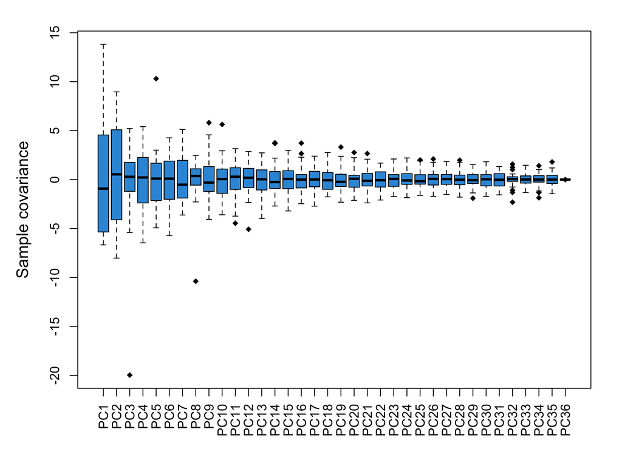

**Figure 2.** Distribution of sample covariance by PCs. Outliers were drawn beyond the boxes. Click link below to see individual outliers.

> Download outlier samples

*[Go to project home](http://zhezhangsh.github.io/RoCA)*

### 2.1.3 Variable loading

Loading (weight) of variables on each PC.

> Full variable loading table (Download)

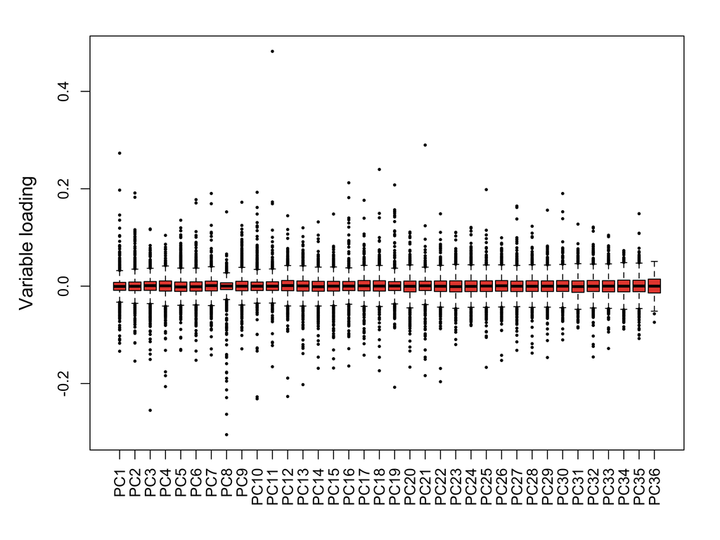

**Figure 3.** Distribution of variable loading by PCs. Outliers drawn beyond the boxes are variables with high contribution to each PC. Click link below to see individual outliers.

> Downlaod high loading variables

*[Go to project home](http://zhezhangsh.github.io/RoCA)*

### 2.1.4 Remove PC

In case a PC is obviously related to a confounder, such as batch effect and gender, its impact can be removed by calculating the residuals of a linear fitting between each variable and each PC. A residual matrix is generated corresponding to the removal of each PC.

> Download residual matrix

*[Go to project home](http://zhezhangsh.github.io/RoCA)*

## 2.2 Plot PCA

Plot covariance of **PC1** and **PC2** and color samples by their characteristics.

### 2.2.1 ID

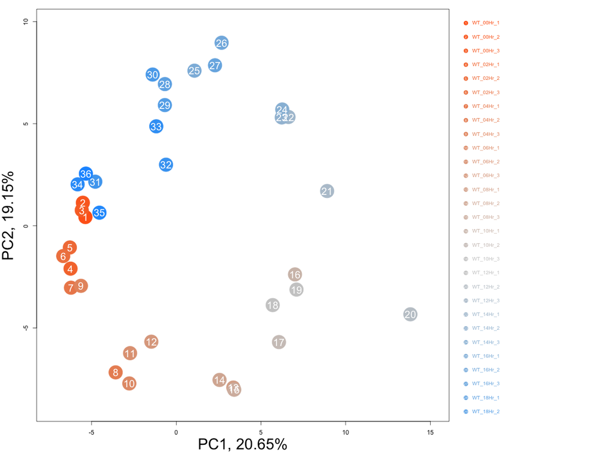

### 2.2.2 Group

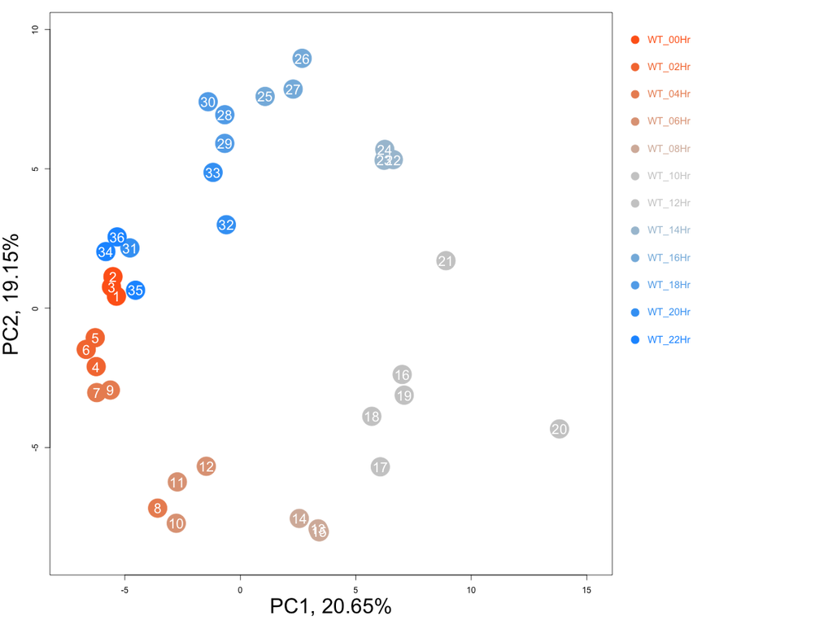

### 2.2.3 Replicate

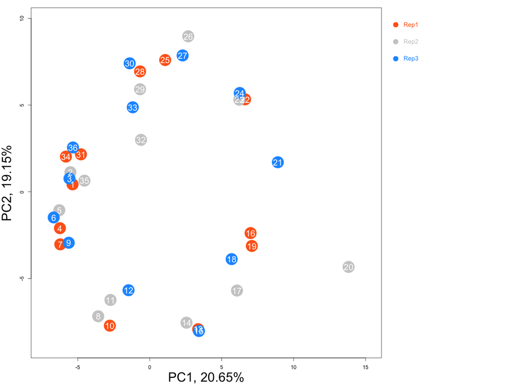

### 2.2.4 Hour

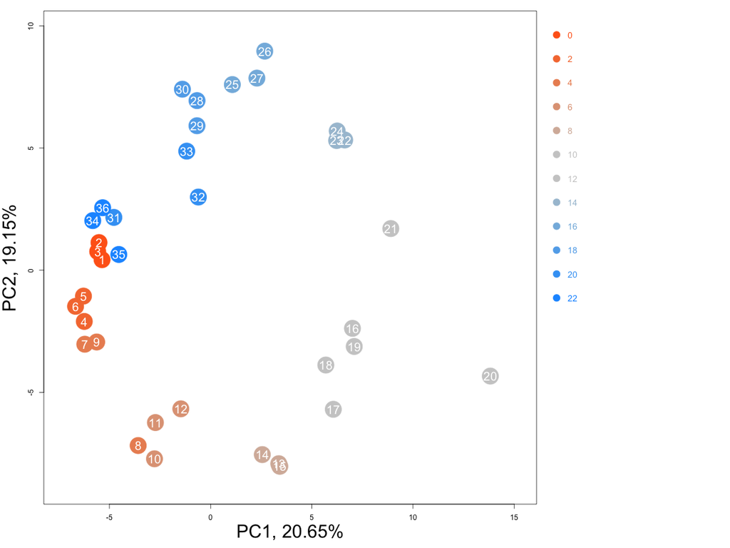

## 2.3 Sample characteristics

**Table 2.** Full sample characteristics (download).

|  | Group | Replicate | Hour |
| --- | --- | --- | --- |
| WT_00Hr_1 | WT_00Hr | Rep1 | 0 |
| WT_00Hr_2 | WT_00Hr | Rep2 | 0 |
| WT_00Hr_3 | WT_00Hr | Rep3 | 0 |
| WT_02Hr_1 | WT_02Hr | Rep1 | 2 |
| WT_02Hr_2 | WT_02Hr | Rep2 | 2 |
| WT_02Hr_3 | WT_02Hr | Rep3 | 2 |
| WT_04Hr_1 | WT_04Hr | Rep1 | 4 |
| WT_04Hr_2 | WT_04Hr | Rep2 | 4 |
| WT_04Hr_3 | WT_04Hr | Rep3 | 4 |
| WT_06Hr_1 | WT_06Hr | Rep1 | 6 |
| WT_06Hr_2 | WT_06Hr | Rep2 | 6 |
| WT_06Hr_3 | WT_06Hr | Rep3 | 6 |
| WT_08Hr_1 | WT_08Hr | Rep1 | 8 |
| WT_08Hr_2 | WT_08Hr | Rep2 | 8 |
| WT_08Hr_3 | WT_08Hr | Rep3 | 8 |
| WT_10Hr_1 | WT_10Hr | Rep1 | 10 |
| WT_10Hr_2 | WT_10Hr | Rep2 | 10 |
| WT_10Hr_3 | WT_10Hr | Rep3 | 10 |
| WT_12Hr_1 | WT_12Hr | Rep1 | 12 |
| WT_12Hr_2 | WT_12Hr | Rep2 | 12 |
| WT_12Hr_3 | WT_12Hr | Rep3 | 12 |
| WT_14Hr_1 | WT_14Hr | Rep1 | 14 |
| WT_14Hr_2 | WT_14Hr | Rep2 | 14 |
| WT_14Hr_3 | WT_14Hr | Rep3 | 14 |
| WT_16Hr_1 | WT_16Hr | Rep1 | 16 |
| WT_16Hr_2 | WT_16Hr | Rep2 | 16 |
| WT_16Hr_3 | WT_16Hr | Rep3 | 16 |
| WT_18Hr_1 | WT_18Hr | Rep1 | 18 |
| WT_18Hr_2 | WT_18Hr | Rep2 | 18 |
| WT_18Hr_3 | WT_18Hr | Rep3 | 18 |
| WT_20Hr_1 | WT_20Hr | Rep1 | 20 |
| WT_20Hr_2 | WT_20Hr | Rep2 | 20 |
| WT_20Hr_3 | WT_20Hr | Rep3 | 20 |
| WT_22Hr_1 | WT_22Hr | Rep1 | 22 |
| WT_22Hr_2 | WT_22Hr | Rep2 | 22 |
| WT_22Hr_3 | WT_22Hr | Rep3 | 22 |

*[Go to project home](http://zhezhangsh.github.io/RoCA)*

# 3 Appendix

Check out the **[RoCA home page](http://zhezhangsh.github.io/RoCA)** for more information.

## 3.1 Reproduce this report

To reproduce this report:

1. Find the data analysis template you want to use and an example of its pairing YAML file [here](https://github.com/zhezhangsh/RoCA/wiki/Templates-and-examples) and download the YAML example to your working directory
2. To generate a new report using your own input data and parameter, edit the following items in the YAML file:
- *output* : where you want to put the output files
- *home* : the URL if you have a home page for your project
- *analyst* : your name
- *description* : background information about your project, analysis, etc.
- *input* : where are your input data, read instruction for preparing them
- *parameter* : parameters for this analysis; read instruction about how to prepare input data
3. Run the code below within *R Console* or *RStudio*, preferablly with a new R session:

```r
if (!require(devtools)) { install.packages('devtools'); require(devtools); }
if (!require(RCurl)) { install.packages('RCurl'); require(RCurl); }
if (!require(RoCA)) { install_github('zhezhangsh/RoCAR'); require(RoCA); }

CreateReport(filename.yaml);  # filename.yaml is the YAML file you just downloaded and edited for your analysis
```

If there is no complaint, go to the *output* folder and open the *index.html* file to view report.

*[Go to project home](http://zhezhangsh.github.io/RoCA)*

*END OF DOCUMENT*